# Section 7 — Gibbs Sampling Investigations

STA5001 Exercise Companion

STA5001 Bayesian & Computational Statistics

These investigations extend the worked examples in the STA5001 lecture notes. Use the section numbers to find the Gibbs updates and model derivations. The code chunks supply data for the investigations.

# 7.2 Constructing a Gibbs sampler

## How measurement precision changes the School A fit

The observed School A effect estimate is 28 SAT-Verbal points with standard error 15. Compare it with a hypothetical repeat study whose estimate is 28 with standard error 7.5. Fit each estimate separately using the model in Section 7.2.2. The observation model is $y_A\mid\theta_A\sim N(\theta_A,s_A^2)$, and the prior is $\theta_A\mid\eta\sim N(\eta,\tau^2)$ with $\tau=10$ and $\eta\sim N(0,400)$. Separate the effect of greater measurement precision from variation between finite Gibbs runs.

1. Derive the two full conditionals for the repeat study. Compare the weight on the common center in the update of $\theta_A$.
2. For each study, find the joint posterior precision $Q$ and linear coefficient $\mathbf b$ for $(\theta_A,\eta)$, so the posterior mean is $Q^{-1}\mathbf b$. Use the joint Normal posterior to calculate $\Pr(\theta_A-\eta>5\mid y_A)$.
3. For each model run the same systematic scan, updating $\theta_A$ and then $\eta$, from $(-10,20)$ and $(40,-10)$ with independent seeds. Estimate the probability from 4,000 retained sweeps per run after 500 initial sweeps. Use the exact probabilities and a plot of the joint draws to explain which differences come from measurement precision and which come from simulation.

## Correct marginals and an incorrect joint posterior

Return to the exact School A posterior in Section 7.2.2 with $\tau=10$ and $s_A=15$. Subtract each marginal posterior mean and divide by its posterior standard deviation to obtain $(U,V)$ from $(\theta_A,\eta)$. Use $Q^{-1}$ to obtain their posterior correlation $\rho$. The correct scan draws $U^+=\rho V+\sqrt{1-\rho^2}\,\epsilon_1$ followed by $V^+=\rho U^++\sqrt{1-\rho^2}\,\epsilon_2$, with fresh independent standard Normal noises. The simultaneous update uses the old $U$ in the second equation.

1. Start with an old pair drawn from the target. For each update rule, derive the two marginal variances and the new covariance. For the simultaneous update, repeat the covariance calculation for an old covariance of $c$ and determine its limiting value over many passes.
2. Compute the target probability $\Pr(U-V>1)$ and the probability under the limiting joint distribution of the simultaneous update. Use the variance of $U-V$ to explain why this event distinguishes the two distributions.
3. Run both schemes for 5,000 passes from $(0,0)$ with separate fixed seeds. After discarding the first 100 pairs, report the two marginal standard deviations, the correlation, and the estimated contrast probability. Use the calculations above to explain which checks would detect the error.

## Pairing effects within Gibbs sweeps

Fit the full Eight Schools model in Section 7.2.3. Use the observed estimates and standard errors below, the center prior $\eta\sim N(0,400)$, and the variance prior $\tau^2\sim\operatorname{IG}(3,200)$ in shape–scale form. Use the three-block scan $(\boldsymbol\theta,\eta,\tau^2)$. Start at $(\eta,\tau)=(-15,2),(0,6),(10,15),(30,30)$, set the four seeds to 7301–7304, and retain 40,000 sweeps per chain after discarding 2,000.

```r
data("eight_schools", package = "BayesComp")
knitr::kable(eight_schools, col.names = c("School", "Estimated effect", "SE"))
```

| School | Estimated effect | SE |
| --- | --- | --- |
| A | 28 | 15 |
| B | 8 | 10 |
| C | -3 | 16 |
| D | 7 | 11 |
| E | -1 | 9 |
| F | 1 | 11 |
| G | 18 | 10 |
| H | 12 | 18 |

1. Estimate $\Pr(\theta_G>\theta_A\mid\mathbf y)$ and the posterior variance of $\theta_G-\theta_A$ from the paired draws.
2. Shuffle the G draws within each chain and repeat both calculations.
3. Use the covariance term in the variance of the contrast and the joint contours in panel A of Figure 7.2.3 to explain the effect of shuffling.

## When did the coal-disaster rate change?

Use annual counts of British coal-mining disasters with at least ten fatalities to estimate when the rate changed and how large the decline was. Before fitting the model, use the plot to identify a plausible span of years for the shift.

**Copy the annual counts into R**

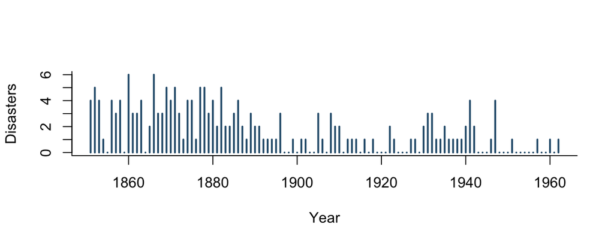

Annual British coal-mining disaster counts, 1851–1962.

```r
coal_disasters <- c(
  4, 5, 4, 1, 0, 4, 3, 4, 0, 6, 3, 3, 4, 0,  # 1851–1864
  2, 6, 3, 3, 5, 4, 5, 3, 1, 4, 4, 1, 5, 5,  # 1865–1878
  3, 4, 2, 5, 2, 2, 3, 4, 2, 1, 3, 2, 2, 1,  # 1879–1892
  1, 1, 1, 3, 0, 0, 1, 0, 1, 1, 0, 0, 3, 1,  # 1893–1906
  0, 3, 2, 2, 0, 1, 1, 1, 0, 1, 0, 1, 0, 0,  # 1907–1920
  0, 2, 1, 0, 0, 0, 1, 1, 0, 2, 3, 3, 1, 1,  # 1921–1934
  2, 1, 1, 1, 1, 2, 4, 2, 0, 0, 0, 1, 4, 0,  # 1935–1948
  0, 0, 1, 0, 0, 0, 0, 0, 1, 0, 0, 1, 0, 1  # 1949–1962
)
coal_year <- 1851:1962
stopifnot(length(coal_disasters) == length(coal_year))
```

The series is based on R. G. Jarrett (1979), “A note on the intervals between coal-mining disasters,” *Biometrika* 66(1), 191–193.

Let $y_i$ be the count in year $1850+i$, with $n=112$. Let $M$ be the final index at the early rate, so $1850+M$ is the last year at that rate. Given $M$, $\lambda_1$, and $\lambda_2$, the counts are independent Poisson with rate $\lambda_1$ through index $M$ and $\lambda_2$ thereafter. Use a uniform prior on $M\in\{1,\ldots,n-1\}$ and independent $\operatorname{Gamma}(0.001,0.001)$ priors on the rates, using shape and rate. In the derivations, write the hyperparameters as $(a_j,b_j)$ for $j=1,2$ and put $S_k=\sum_{i=1}^k y_i$.

1. **Construct and run the sampler.** Derive the two Gamma conditionals and the categorical conditional for $M$. Explain why the rates can be updated together given $M$. Update $(\lambda_1,\lambda_2)$ first and then $M$, starting at $M=56$ with seed 7311. Use log weights for the categorical update. Discard 2,000 initial sweeps and retain 10,000. On a scatterplot of the rate pairs, mark the first ten completed sweeps in order and show where the retained pairs lie.
2. **Check the date of the shift.** Integrate out the rates to show that

   $$\Pr(M=k\mid\mathbf y)\propto
   \frac{\Gamma(a_1+S_k)}{(b_1+k)^{a_1+S_k}}
   \frac{\Gamma(a_2+S_n-S_k)}{(b_2+n-k)^{a_2+S_n-S_k}}.$$

   Normalize over the candidate years. Compare the exact probabilities and the Gibbs frequencies on common axes. Report the median and 95% equal-tail posterior interval for the last year at the early rate. Explain how drawing $M$ from these probabilities and then drawing the rates gives independent complete posterior draws.
3. **Check the size of the decline.** Estimate $\Pr(\lambda_2<\lambda_1/3\mid\mathbf y)$ from the complete Gibbs states. For an independent check, write $(A_{jk},B_{jk})$ for the shape and rate of $\lambda_j$ given $M=k$. Scale both Gamma variables to unit rate and use the resulting Beta ratio to show that, for $c>0$,

   $$\Pr(\lambda_2<c\lambda_1\mid M=k,\mathbf y)
   = F_{\operatorname{Beta}(A_{2k},A_{1k})}
   \!\left(\frac{c B_{2k}}{B_{1k}+c B_{2k}}\right).$$

   Average this probability over the exact distribution of $M$ with $c=1/3$. Compare with the fraction of complete Gibbs sweeps satisfying the event and explain why that estimate uses paired rates.

# 7.3 Invariance and convergence of Gibbs sweeps

## Diagnosing an unexplored part of the support

Can Gibbs summaries agree with the target when the chain has missed part of its support? Use the four-state family in lecture Section 7.3.5. In the state order $(0,0),(0,1),(1,0),(1,1)$, the target masses are $((1-\varepsilon)/2,\varepsilon/2,\varepsilon/2,(1-\varepsilon)/2)$. Compare $\varepsilon=0.02$ and $\varepsilon=0$. Begin with a sweep that updates $X$ given $Y$ and then $Y$ given the new $X$.

1. **Track two summaries exactly.** For each target and each start, $(0,0)$ and $(1,1)$, compute $\Pr(X_s=Y_s)$ and $\Pr(Y_s=1)$ after $s=1$ and $s=10$ sweeps. Use the mixture of the two transition rows and the recurrence for $p_s=\Pr(Y_s=1)$ from Section 7.3.5. Which summary reveals dependence on the start?
2. **Check the transition behavior.** With a fixed seed, run 2,000 independent ten-sweep chains for each combination of target, scan order ($X$ then $Y$, or $Y$ then $X$), and start. For $\varepsilon=0.02$, compare the fraction ending at the opposite diagonal corner with the corresponding entry of the ten-sweep transition matrix. For $\varepsilon=0$, pool the final states from equally many chains started at each corner. Explain how the pooled summaries can agree with the target even when no chain crosses.
3. **Change the block.** Replace the two coordinate updates by a single exact draw of $(X,Y)$ from the target. Give the distribution after one sweep from each start. Use the support to explain why drawing one joint block changes what the chain can reach.

# 7.4 Gibbs sampling for multivariate and hierarchical models

## Levels of replication and joint updating

Return to the Project STAR case study in Section 7.4.3. Let $Y_{ijk}$ be the kindergarten mathematics score transformed to $(\text{score}-500)/50$ for pupil $i$ in classroom $j$ of school $k$. Let $T_{jk}=1$ for a small class and $T_{jk}=0$ for a regular class without an aide. Assume conditional independence within each layer of
$$\begin{aligned}
Y_{ijk}\mid \theta_{jk},\sigma^2 &\sim N(\theta_{jk},\sigma^2),\\
\theta_{jk}\mid\mu_k,\beta,\tau_c^2 &\sim N(\mu_k+\beta T_{jk},\tau_c^2),\\
\mu_k\mid\eta,\tau_s^2 &\sim N(\eta,\tau_s^2).
\end{aligned}$$
The five independent priors are $N(0,1)$ for each of $\eta,\beta$ and $\operatorname{InvGamma}(3,b)$ for the three variances, with $b=2,0.18,0.5$ for $\sigma^2,\tau_c^2,\tau_s^2$, respectively. The second inverse-Gamma parameter $b$ is the rate of the reciprocal variable.

The starter data give unrounded summaries for the 28 classrooms in Section 7.4.3. They use kindergarten mathematics scores from the [archived Project STAR student file](https://dataverse.harvard.edu/api/access/datafile/666716) and follow the selection rule given there. The data describe 474 pupils in eight schools. For each class they give its type, number of observed scores, mean transformed score, and within-class sum of squared deviations. Use these summaries for all three sampler designs.

```r
star <- read.csv(text = '
school,class,small,n,mean,within_ss
A,1,0,20,-0.366,10.12008
A,2,1,13,-0.235384615384615,9.51852307692308
A,3,1,17,-0.295294117647059,14.9380235294118
B,1,1,16,0.0225,6.8991
B,2,0,19,0.288421052631579,9.03945263157895
B,3,1,16,0.71875,8.894775
B,4,0,21,0.289523809523809,14.8604952380952
C,1,1,13,-0.509230769230769,5.70769230769231
C,2,0,24,-0.525833333333333,11.8731833333333
C,3,1,17,-0.394117647058824,7.91101176470588
D,1,0,22,-0.0227272727272728,15.6482363636364
D,2,1,13,1.00307692307692,15.1950769230769
D,3,0,20,-0.0809999999999999,20.04598
D,4,1,11,0.405454545454545,7.99127272727273
E,1,0,19,0.0210526315789473,9.79717894736842
E,2,1,12,-0.345,10.2673
E,3,1,12,-0.145,3.3337
F,1,1,13,-0.941538461538461,4.18036923076923
F,2,0,21,-0.840952380952381,12.124380952381
F,3,1,14,-0.207142857142857,9.99408571428572
G,1,0,21,0.02,14.3744
G,2,1,13,-0.436923076923077,7.05507692307692
G,3,1,15,-0.522666666666667,14.9526933333333
H,1,1,17,0.663529411764706,16.9849882352941
H,2,0,23,-0.400869565217391,17.4099826086957
H,3,0,20,-0.288,8.59872
H,4,1,15,-0.196,7.66416
H,5,1,17,0.169411764705882,11.3656941176471
')
```

1. **Predict at two levels.** For a class of fixed type $t$, derive the conditional predictive distributions of a pupil score in a new classroom at an observed school and of a pupil score in a new classroom at a new school. Apply total variance to include posterior uncertainty in $\mu_k+\beta t$ or $\eta+\beta t$, respectively. Work on the transformed score scale.
2. **Identify the joint precision.** At fixed variances, derive the joint Normal precision matrix for the classroom means, school means, population center, and class-size coefficient. Identify the off-diagonal entries involving $\beta$ and which classrooms contribute to them.
3. **Examine the non-centered school effects.** Write $\mu_k=\eta+\tau_s Z_k$, with independent $Z_k\sim N(0,1)$ a priori. At fixed $(\eta,\beta,\tau_s,\tau_c)$ and classroom means, derive the conditional mean and variance of $Z_k$. Compare the variance when $\tau_c^2/J_k$ is large or small relative to $\tau_s^2$, where $J_k$ counts classrooms in school $k$.
4. **Compare at equal elapsed time.** Implement the separate centered updates, the joint centered update, and the update that non-centers the school means, using the Gibbs algorithms in Section 7.4.3. Estimate the posterior mean of the school variance share $\tau_s^2/(\sigma^2+\tau_c^2+\tau_s^2)$. Use the four starts and warm-up rule under *Mixing checks* in Section 7.4.3. Give each design the same elapsed sampling budget after warm-up. Keep MCSE batches within chains (Section 8.4.3). Report elapsed time, retained draws, the estimated mean, and its MCSE for each design.
5. **Change the school-variance prior.** Change only the prior on $\tau_s^2$ to $\operatorname{InvGamma}(3,1)$. Use one of the samplers to compare the posterior means of $\beta$ and the school variance share under the two priors. Use independent runs and assess the estimated differences relative to their MCSEs.

Rendered with R 4.6.0 and BayesComp 0.1.0.